# CoGAPS Workflow Vignette

Genevieve L. Stein-O’Brien

7 June 2018

#### Package version: CoGAPS 3.1.2

# 1 Introduction

Gene Association in Pattern Sets (GAPS) infers underlying patterns in a matrix of measurements that can be interpreted as arising from the multiplication of two lower dimensional matrices. The first development of this code in R/Biocondcutor was focused on gene expression analysis, however the original concept was used in spectral imaging. The approach is a general form of matrix factorization using a stochastic algorithm. In this vignette, we will focus on gene expression analysis for concreteness, but the factorization is applicable more broadly.

The Markov chain Monte Carlo (MCMC) matrix factorization that infers patterns also infers the extent to which individual genes belong to these patterns. The CoGAPS algorithm extends GAPS to infer the coordinated activity in sets of genes for each of the inferred patterns based upon (5) and to refine gene set membership based upon (2).

The GAPS algorithm is implemented in C++ and compiled and integrated into R using the Rcpp package. GAPS is licensed under the GNU General Public License version 2. You may freely modify and redistribute GAPS under certain conditions that are described in the top level source directory file COPYING.

If you use the CoGAPS package for your analysis please cite: (1) EJ Fertig, J Ding, AV Favorov, G Parmigiani, and MF Ochs (2010) CoGAPS: an R/C++ package to identify patterns and biological process activity in transcriptomic data. Bioinformatics 26: 2792-2793.

To cite the CoGAPS algorithm use: (3) MF Ochs (2003) Bayesian Decomposition in The Analysis of Gene Expression Data: Methods and Software G Parmigiani, E Garrett, R Irizarry, and S Zeger, ed. New York: Springer Verlag.

To cite the gene set statistic use: (5) MF Ochs, L Rink, C Tarn, S Mburu, T Taguchi, B Eisenberg, and AK Godwin (2009) Detection of treatment-induced changes in signaling pathways in gastrointestinal stromal tumors using transcriptomic data. Cancer Research 69: 9125-9132.

To site the set-membership refinement statistic use: (2) EJ Fertig, AV Favorov, and MF Ochs (2012) Identifying context-specific transcription factor targets from prior knowledge and gene expression data. 2012 IEEE International Conference on Bioinformatics and Biomedicine, B310, in press. Please contact Elana J. Fertig ejfertig@jhmi.edu or Michael F. Ochs ochsm@tcnj.edu for assistance.

# 2 CoGAPS

Here we read data into an R object, but we are currently adding support for passing a file name (.csv, .tsv, .mtx) for the data. This data comes with an uncertainty matrix (GIST.S) but we are also working on allowing just the data matrix to be passed.

```r
suppressMessages(library(CoGAPS))
print(packageVersion("CoGAPS"))
```

```
## [1] '3.1.2'
```

## 2.1 Loading Sample Data

Here we read in an example dataset: the `GIST` dataset from Ochs et al. (2009). contains gene expression data from gastrointestinal stromal tumor cell lines treated with Gleevec. The matrix contains 1363 genes by 9 samples of mean gene expression data.

```r
data("GIST")
```

## 2.2 Running CoGAPS

Here we run CoGAPS on the data set `GIST.D` for a few different values of nFactor (if the data matrix is M x N, then we find D = A * P, where A is M x nFactor and P is nFactor x N). Typically we run for 50000 iterations but we are also working on dynamically selecting the number of iterations so that the user can just pass a “max iterations” parameter if they choose, otherwise it will be handled internally.

```r
nIterations <- 2500
patternRange <- 2:4
cogapsResult <- list()
for (nPatterns in patternRange)
{
    cogapsResult[[nPatterns]] <- CoGAPS(as.matrix(GIST.D),
        as.matrix(GIST.S), nFactor=nPatterns, nSample=nIterations,
        nEquil=nIterations, seed=123, messages=FALSE)
}
```

## 2.3 Selecting Number of Patterns

Selecting the best value for nFactor (i.e. number of patterns) is the most difficult part of the analysis, as too many patterns are hard to analyze and too few do not show a comprehensive picture. Here we show the simplest approach of selecting dimensionality by plotting the error and selecting the least number of patterns that sufficiently reduce the error.

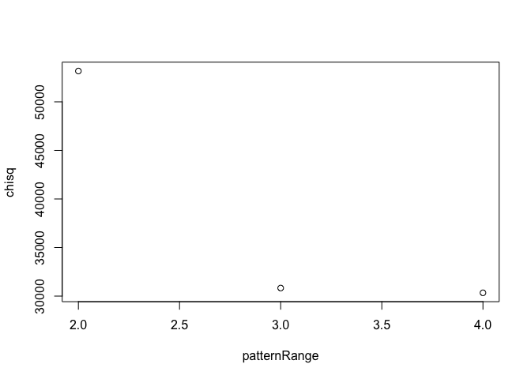

```r
chisq <- sapply(patternRange, function(i) cogapsResult[[i]]$meanChi2)
plot(patternRange, chisq)
```

In this example, we can see that 3 is the optimal number of patterns (nFactor), with significantly less error than with 2 patterns.

```r
bestResult <- cogapsResult[[3]]
```

## 2.4 Plotting outputs

Here we plot 3 patterns with their associated amplitudes.

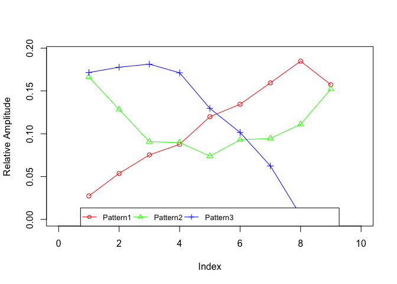

```r
# pdf("GIST_example.pdf") # uncomment to save file to pdf
plotP(bestResult$Pmean)
```

```r
# dev.off() # uncomment to save file to pdf
```

# 3 Using CoGAPS-based statistics to infer gene membership in annotated gene sets

## 3.1 CoGAPSStat

The function `calcCoGAPSStat` is used to infer gene set activity in each pattern from the GAPS matrix factorization.
$$calcCoGAPSStat(Amean, Asd, GStoGenes, numPerm=500)$$
`calcCoGAPSStat` calculates the gene set statistics for each column of a matrix A using a Z-score from the elements of the A matrix, the input gene set and permutation tests. The function outputs a list containing GSUpreg, GSDownreg, and GSActEst.

- *GSUpreg* lists p-values for upregulation of each gene set in each pattern
- *GSDownreg* lists p-values for downregulation of each gene set in each pattern
- *GSActEst* provides gene set activity through conversion of p-values to activity estimates of each gene set in each pattern

```r
data("SimpSim")
stat <- calcCoGAPSStat(SimpSim.result$Amean, SimpSim.result$Asd, GStoGenes=GSets, numPerm=500)
```

## 3.2 computeGeneGSProb

Now using the `computeGeneGSProb` function, we can use the gene set statistic (returned from calcCoGAPSStat) to compute a statistic to quantify the likely membership of each gene annotated to a set based on its inferred activity.
$$computeGeneGSProb(Amean, Asd, GStoGenes, numPerm=500)$$
The statistic used to infer membership compares the expression pattern of a gene annotated as a member of a gene set to the common expression pattern of all annotated members of that gene set. The function outputs the p-value of a set membership for each gene specified in GStoGenes.